# Успешность проектов на платформе Kickstarter

Кемпи Елена, eakempi

### Задача

На основе данных постараться:

- провести анализ данных с Kickstarter;
- выяснить, какие параметры влияют на успешность сбора средств для проекта;
- построить дерево решений, предсказывающее статус проекта, наберет ли он нужную сумму или нет;
- выяснить, какие предсказания будут для разных групп проектов.

### Вопросы

- Что влияет на успешность проекта, наберет ли он нужную сумму?
- Каковы условия нужны для того, чтобы проект был успешен?

### Загрузка данных и преобразование

Набор данных состоит из 43335 проектов со информацией о следующих характеристиках:

- ID на Kickstarter (id)
- Название проекта (name)
- Категория проекта (category)
- Главная категория кампании (main_category)
- Валюта, в которой идет спонсирование проекта (currency)
- Крайний срок для краудфандинга (deadline)
- Сумма денег, необходимая создателю для завершения своего проекта (goal)
- Дата запуска (launched)
- Текущее состояние проекта (state)
- Количество спонсоров (backers)
- Страна для финансирования (country)

Преобразуем все текстовые переменные, кроме deadline и name, в категории, а deadline - в формат даты. Название проекта оставим как текст.

Для проведения дальнейшего анализа добавим новые колонки с целевой суммой в долларах США, с указанием длительности сбора средств на проект (Period), времени года старта (Season_launched) и окончания (Season_deadline) сбора средств, а так же длины названия, ведь короткое название может зацепить или, наоборот, не дать полное понимание задумки, повлияв на успешность. Уберем колонки с валютой, целевой суммой в валюте страны (goal) и с id (id), чтобы они не мешали анализу.

### Анализ

Перед тем как строить модель, опеределяющую успешность сбора средств для проекта, проверим, правда ли что не все проекты успешны.

H0: Все проекты успешны, т.е. собирают нужную сумму.

H1: Не все проекты успешны, не все собрают нужную сумму.

|  | failed | successful |
| --- | --- | --- |
| successful | 24906 | 18429 |

| x |
| --- |
| 0.4252683 |

Так как accuracy небольшое (примерно 0.43), мы отвергаем нулевую гипотезу. Так как не все проекты успешны, мы должны найти, что влияет на успешность. Основные факторы, которые, возможно, могут влиять на результаты сбора средств для проектов:

- Главная категория кампании
- Категория проекта
- Страна
- Целевая сумма сбора средств
- Период, за который должны были быть собраны деньги
- Времен года, когда был запущен и закончен сбор средств

Следовательно, вопросы будут следующими:

- Зависит ли успешность от главной категории кампании?
- Зависит ли успешность от категории проекта?
- Зависит ли успешность от страны?
- Зависит ли успешность от целевой суммы сбора средств?
- Зависит ли успешность от периода, за который должны были быть собраны деньги?
- Зависит ли успешность от времени года, когда был запущен сбор средств?
- Зависит ли успешность от времени года, когда был завершен сбор средств?
- Зависит ли успешность от длины названия проекта?

Для ответа на вопрос, проверим, существует ли зависимость этих переменных на состояние проекта, случайно ли такое распределение, проверив несколько гипотез. Для проверки гипотез воспользуемся статистическими тестами, чтобы узнать, является ли такое распределение случайным, и графиками, чтобы посмотреть, как переменные влияют на успешность. В результате статистических тестов будем находить p-value, которое показывает вероятность получить эффект случайно (неслучайно, если p-value < 0.05).

#### Поиск ответа на вопросы, проверка гипотез

##### Вопрос 1

**Вопрос:** Зависит ли успешность от главной категории кампании?

H0: Успешность проекта не зависит от главной категории кампании.

H1: Успешность проекта зависит от главной категории кампании.

Построим график, чтобы посмотреть, есть ли зависимость и проверим, могло ли распределение получится случайно.

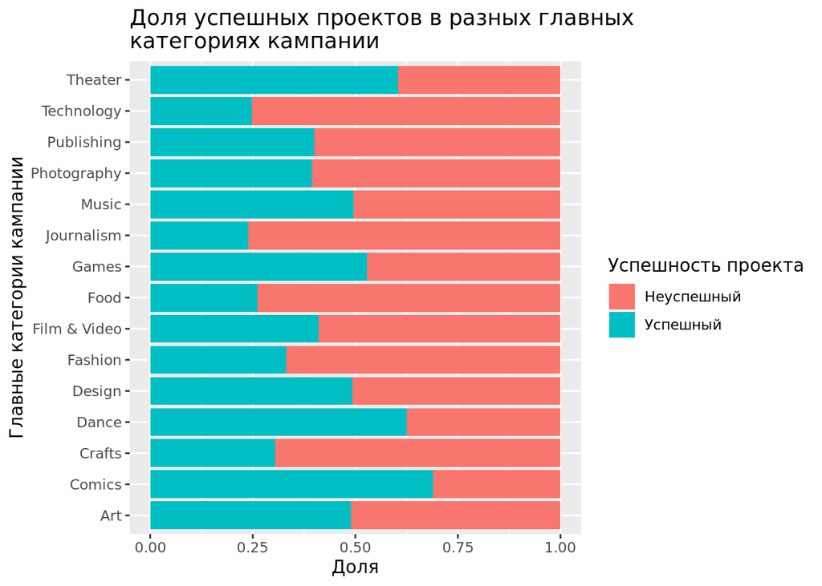

```
##
##  Asymptotic General Independence Test
##
## data:  state by
##   main_category (Art, Comics, Crafts, Dance, Design, Fashion, Film & Video, Food, Games, Journalism, Music, Photography, Publishing, Technology, Theater)
## maxT = 26.003, p-value < 0.00000000000000022
## alternative hypothesis: two.sided
```

Из графика мы видим, что в разных главных категориях разное соотношение между успешными и проваленными проектами. Статистический тест показал, что p-value < 0.05, такое распределение не могло получится случайно. Мы отвергаем нулевую гипотезу о том, что зависимости нет, и можем использовать эту переменную для построения дерева. Самыми успешными являются проекты в категории *Theater (Театр)*, *Dance (Танец)*, *Comics (Комиксы)*.

**Ответ:** Успешность проекта зависит от главной категории кампании.

**Вывод:** Так как существует зависимость успешности сбора средств для проекта от главной категории кампании. Можем использовать данную категорию для построения дерева. Самыми успешными являются проекты в категории *Theater (Театр)*, *Dance (Танец)*, *Comics (Комиксы)*.

##### Вопрос 2

**Вопрос:** Зависит ли успешность от категории проекта?

H0: Успешность проекта не зависит от категории проекта.

H1: Успешность проекта зависит от категории проекта.

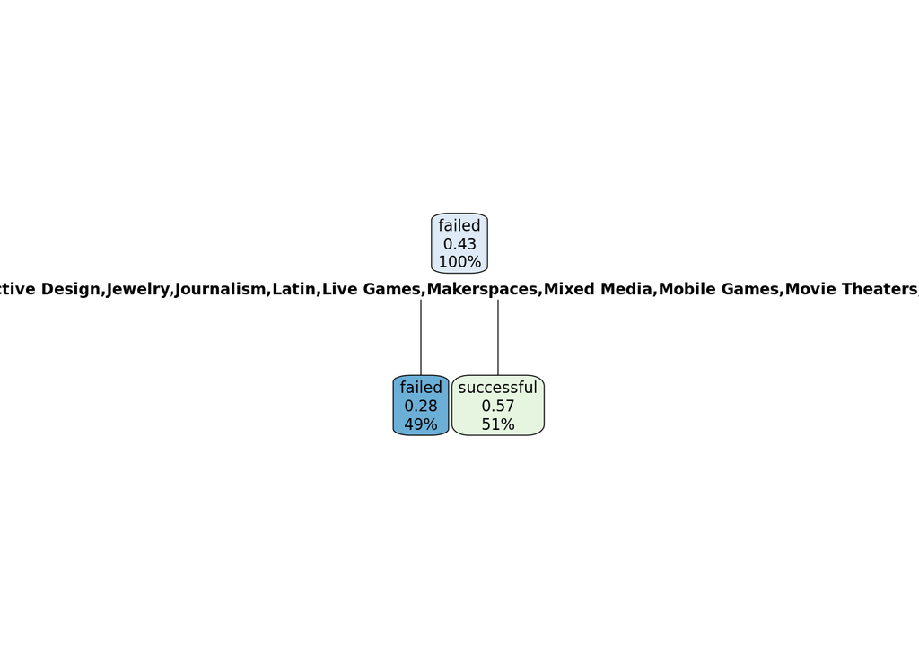

```
##
##  Asymptotic General Independence Test
##
## data:  state by
##   category (3D Printing, Academic, Accessories, Action, Animals, Animation, Anthologies, Apparel, Apps, Architecture, Art, Art Books, Audio, Bacon, Blues, Calendars, Camera Equipment, Candles, Ceramics, Children's Books, Childrenswear, Chiptune, Civic Design, Classical Music, Comedy, Comic Books,…
## maxT = 34.012, p-value < 0.00000000000000022
## alternative hypothesis: two.sided
```

Построив дерево мы видим, что зависимость есть. Статистический тест показал, что p-value < 0.05, значит такое распределение не могло получится случайно. Так как различных категорий очень много, их использование как условие определения успешности не принесет хороших результатов.

**Ответ:** Успешность проекта зависит от категории проекта.

**Вывод:** Хоть есть зависимость успешности проекта от категории, из-за количества различных категорий не стоит использовать ее для дерева.

##### Вопрос 3

**Вопрос:** Зависит ли успешность от страны?

H0: Успешность проекта не зависит от страны.

H1: Успешность проекта зависит от страны.

Построим график, чтобы посмотреть доли успешных проектов в разных странах, и проверим, могла ли зависимость получится случайно.

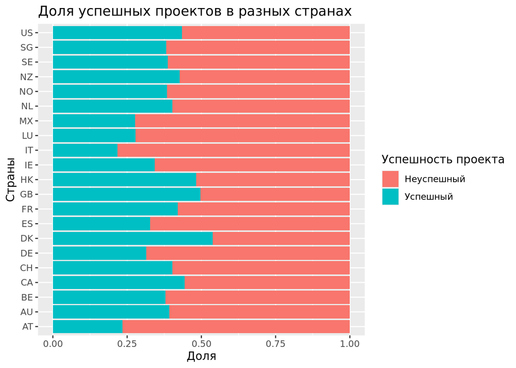

```
##
##  Asymptotic General Independence Test
##
## data:  state by
##   country (AT, AU, BE, CA, CH, DE, DK, ES, FR, GB, HK, IE, IT, LU, MX, NL, NO, NZ, SE, SG, US)
## maxT = 12.154, p-value < 0.00000000000000022
## alternative hypothesis: two.sided
```

**Ответ:** Существует зависимость успешности проекта от страны.

**Вывод:** Так как успешность зависит от страны, мы можем использовать данную категорию для построения дерева. *Самые успешные проекты в Дании (DK)*, в то время как страны *с самым низким показателем успешности проектов - Люксембург (LU), Италия (IT), Австрия (AT)*.

##### Вопрос 4

**Вопрос:** Зависит ли успешность от целевой суммы сбора средств?

H0: Успешность проекта не зависит от целевой суммы сбора средств.

H1: Успешность проекта зависит от целевой суммы сбора средств.

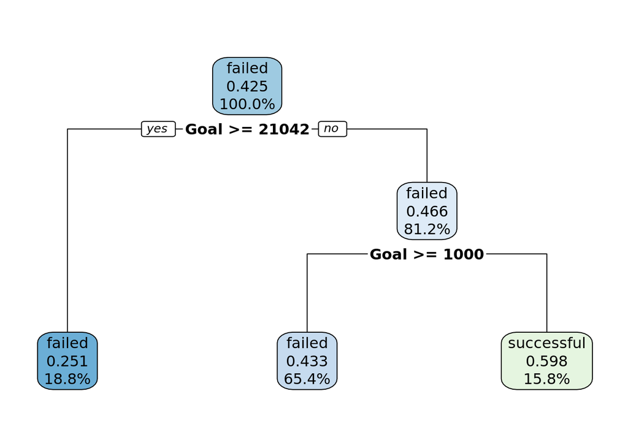

```
##
##  Asymptotic General Independence Test
##
## data:  state by Goal
## Z = 4.8233, p-value = 0.000001412
## alternative hypothesis: two.sided
```

Статистический тест показал, что p-value < 0.05, значит такое распределение не могло получится случайно. Мы видим, что разделение по переменной Goal действительно помогает определить успешность проекта, поэтому используем ее при построении большего дерева.

**Ответ:** Успешность проекта зависит от целевой суммы сбора средств.

**Вывод:** Так как существует зависимость между успешностью проекта и целевой суммы сбора средств, мы можем использовать данную категорию для построения дерева.

##### Вопрос 5

**Вопрос:** Зависит ли успешность от периода, за который должны были быть собраны деньги?

H0: Успешность проекта не зависит от периода, за который должны были быть собраны деньги.

H1: Успешность проекта зависит от периода, за который должны были быть собраны деньги.

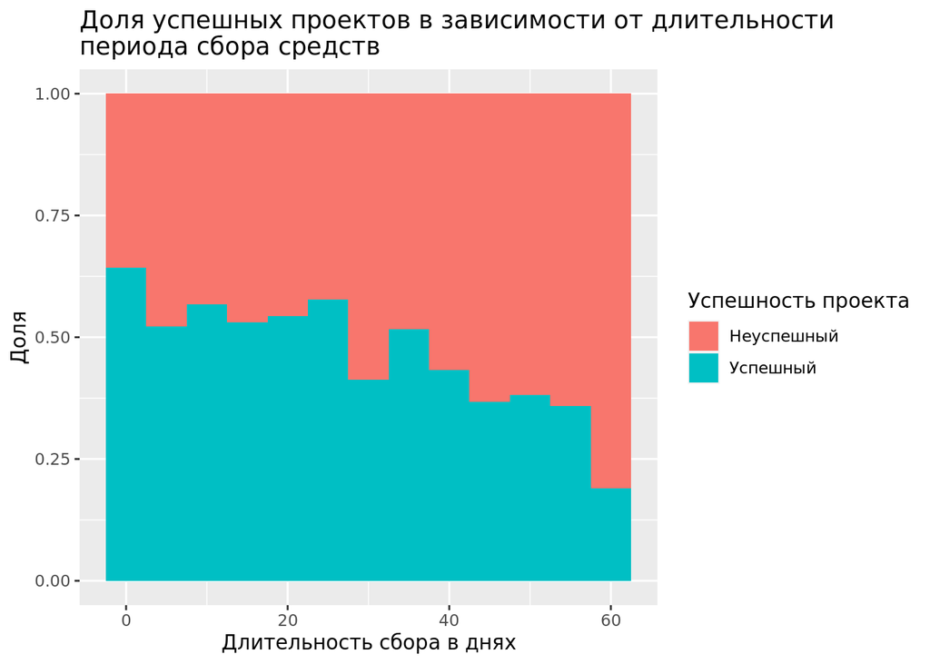

```
##
##  Asymptotic General Independence Test
##
## data:  state by Period
## Z = 32.278, p-value < 0.00000000000000022
## alternative hypothesis: two.sided
```

Статистический тест показал, что p-value < 0.05, значит зависимость между двумя переменными есть. Отвергаем нулевую гипотезу о том, что успешность проекта не зависит от целевой суммы. Из графика мы видим, что проекты, нацеленные собрать средства за меньшее время, более успешны.

**Ответ:** Успешность проекта зависит от периода, за который должны были быть собраны деньги.

**Вывод:** Так как существует зависимость успешности проекта от периода, за который должны были быть собраны деньги, мы можем использовать данную категорию для построения дерева. На основе данных мы можем сказать, что проекты, нацеленные собрать средства за меньшее время, более успешны.

##### Вопрос 6

**Вопрос:** Зависит ли успешность от времени года, когда был запущен сбор средств?

H0: Успешность проекта не зависит от времени года, когда был запущен сбор средств.

H1: Успешность проекта зависит от времени года, когда был запущен сбор средств.

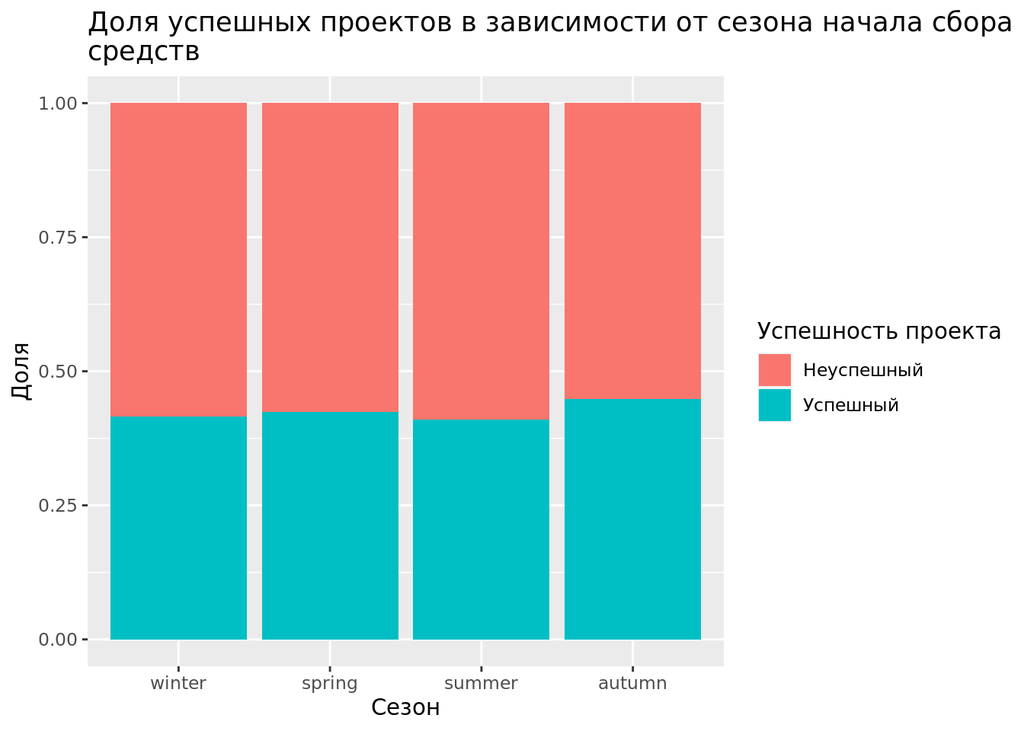

```
##
##  Asymptotic General Independence Test
##
## data:  state by
##   Season_launched (winter, spring, summer, autumn)
## maxT = 5.8795, p-value = 0.00000001175
## alternative hypothesis: two.sided
```

Хоть тест показал, что такое распределение не могло получится случайно, по графику мы видим, что нет большой разницы между проектами, у которых сбор средств был запущен в разные сезоны. Нулевая гипотеза верна, успешность проекта не зависит от времени года, когда был начат сбор средств.

**Ответ:** Успешность проекта не зависит от времени года, когда был запущен сбор средств.

**Вывод:** Так как зависимости не наблюдается, не будем использовать данную категорию для построения дерева.

##### Вопрос 7

**Вопрос:** Зависит ли успешность от времени года, когда был завершен сбор средств?

H0: Успешность проекта не зависит от времени года, когда был завершен сбор средств.

H1: Успешность проекта зависит от времени года, когда был завершен сбор средств.

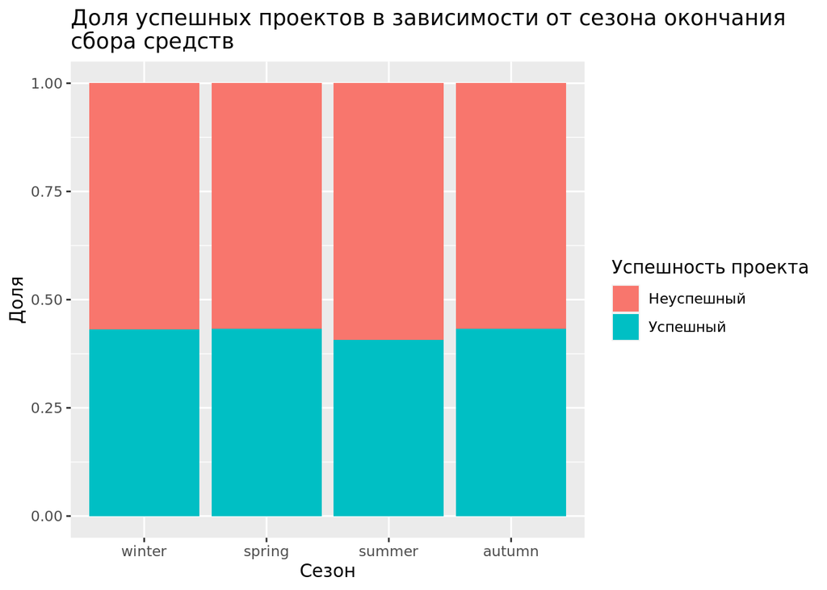

**Ответ:** Успешность проекта не зависит от времени года, когда был завершен сбор средств.

**Вывод:** Так как зависимости нет, не будем использовать данную категорию для построения дерева.

##### Вопрос 8

**Вопрос:** Зависит ли успешность от длины названия проекта?

H0: Успешность не зависит от длины названия проекта.

H1: Успешность зависит от длины названия проекта.

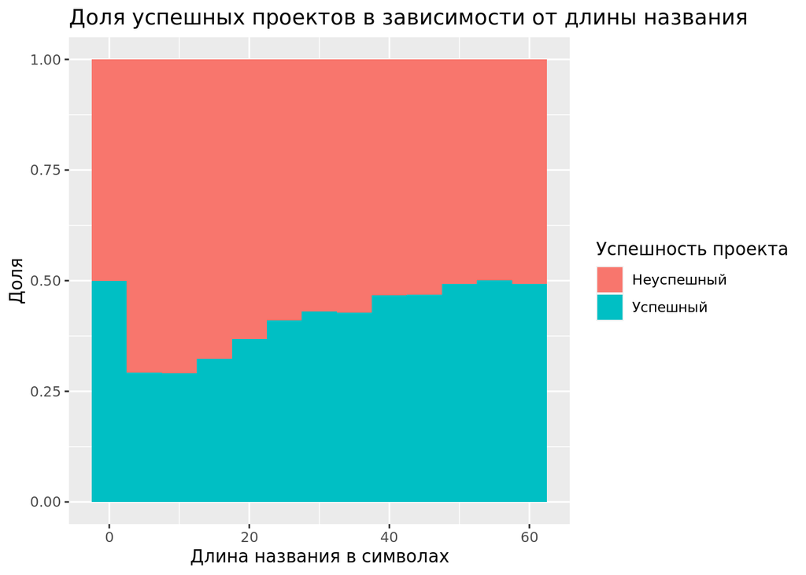

```
##
##  Asymptotic General Independence Test
##
## data:  state by Number_name
## Z = -26.747, p-value < 0.00000000000000022
## alternative hypothesis: two.sided
```

Статистический тест показал, что такое распределение не случайно. По графику мы видим, что проекты с короткими названиями менее успешны в сборе средств, за исключением очень коротких (меньше 5 символов). Отвергаем нулевую гипотезу о том, что успешность не зависит от длины названия проекта, потому что зависимость есть.

**Ответ:** Успешность зависит от длины названия проекта.

**Вывод:** Зависимость между успешностью сбора средств для проекта и длины названия проекта существет. По графику мы видим, что проекты с короткими названиями менее успешны в сборе средст, за исключением очень коротких (меньше 5 символов). Можем использовать данную категорию для построения дерева.

### Построение дерева

Разделим датасет на тестовую и обучающие выборки:

Построим дерева на основании проверенных гипотез, а именно:

- Успешность зависит от главной категории кампании.
- Успешность зависит от категории проекта.
- Успешность зависит от страны.
- Успешность зависит от целевой суммы сбора средств.
- Успешность зависит от периода, за который должны были быть собраны деньги.
- Успешность зависит от длины названия проекта.

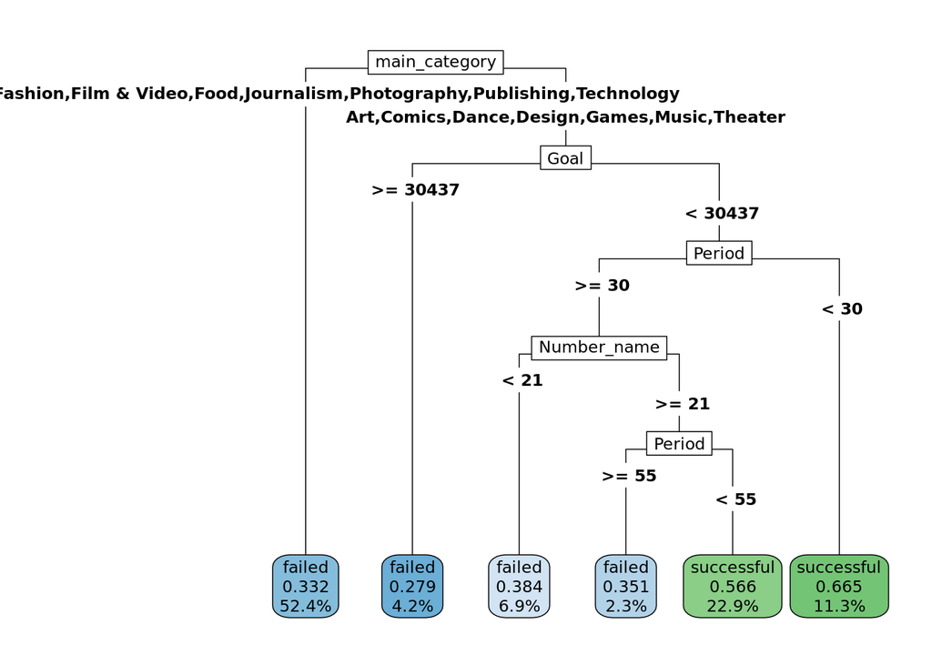

Из дерева мы видим, что страна не влияет на успешность проекта. Проверим точность модели на обучающей выборке.

|  | failed | successful |
| --- | --- | --- |
| failed | 15177 | 7633 |
| successful | 4759 | 7099 |

| x |
| --- |
| 0.6425522 |

Точность модели 0.6425522 (около 64%) на обучающей выборке.

Посмотрим на сложность дерева и вероятность ошибки.

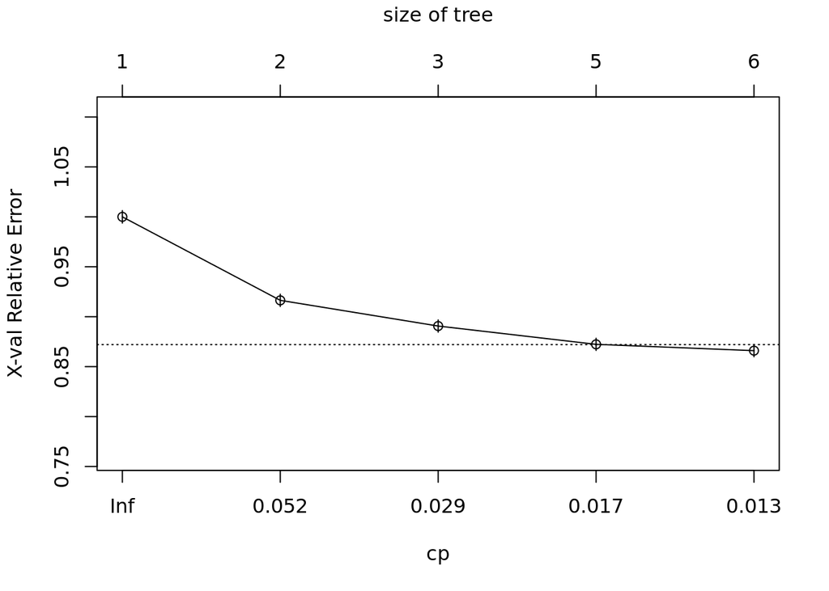

Попробуем улучшить модель, увеличив ее сложность, и сравним точность (accuracy).

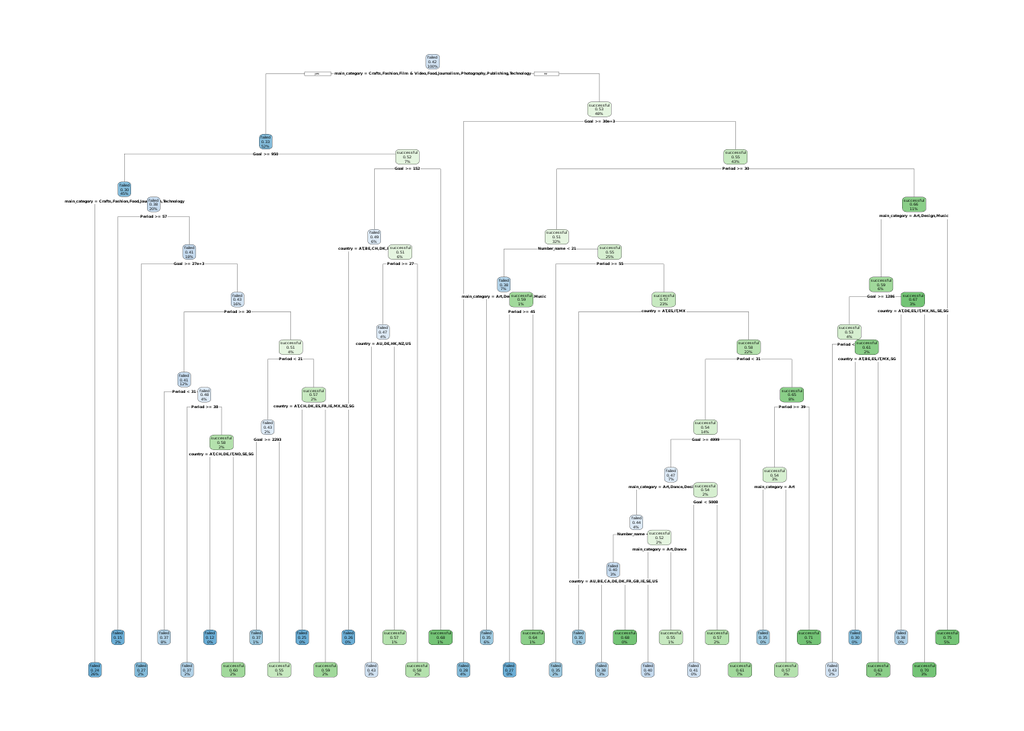

|  | failed | successful |
| --- | --- | --- |
| failed | 15372 | 6629 |
| successful | 4564 | 8103 |

| x |
| --- |
| 0.6771374 |

Дерево стало гораздо сложнее, но точность (0.6771374) увеличилась ненамного. Вернемся к первоначальной модели. Проверим точность не только на обучающей, но и на тестовой выборке.

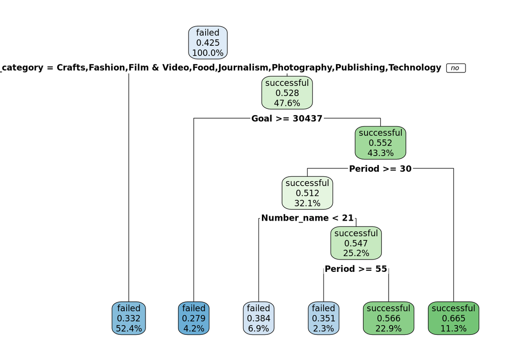

**Обучающая выборка**

|  | failed | successful |
| --- | --- | --- |
| failed | 15177 | 7633 |
| successful | 4759 | 7099 |

| x |
| --- |
| 0.6425522 |

**Тестовая выборка**

|  | failed | successful |
| --- | --- | --- |
| failed | 3774 | 1958 |
| successful | 1196 | 1739 |

| x |
| --- |
| 0.6360909 |

Точность модели 0.6425522 (около 64%) на обучающей выборке и 0.6360909 (около 64%) на тестовой выборке. Модель не переобучена. Однако нельзя очень точно предсказать, собирет ли проект нужную сумму, если есть возможность выбирать главную категорию кампании, целевую сумму, период, за который можно собрать нужную сумму. Модель показывает **как можно увеличить свои шансы на успех**, а именно:

Не выбирать категории Crafts, Fashion, Film & Video, Food, Journalism, Photography, Publishing, Technology (то есть выбрать Art, Comics, Dance, Design, Games, Music, Theater), иметь целевую сумму меньше 30437 и:

1. если собирать деньги меньше 30 дней, то возможность успеха около 67 процентов.
2. если собирать деньги больше 30 дней, то тогда, чтобы быть успешным (с вероятностью около 57 процентов), надо назвать проект длиной не меньше 21 символа и собирать деньги меньге чем 55 дней.

В остальных случаях вероятность провала больше.

В процессе постройки модели мы не рассмотрели перменную backers, которая показывает количество спонсоров.

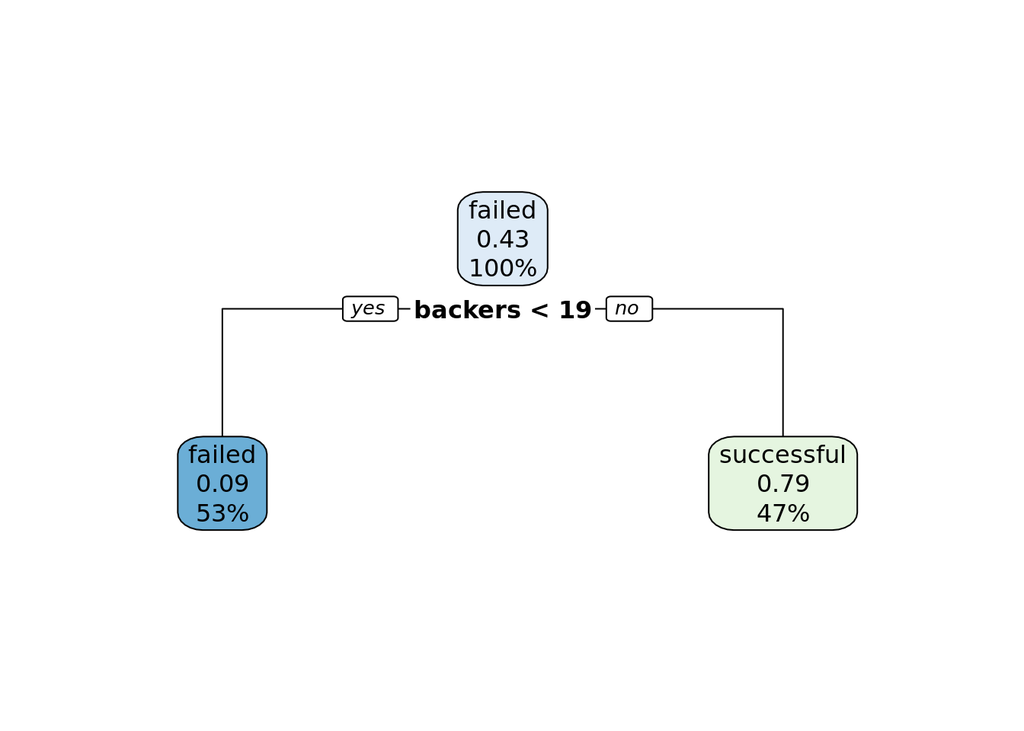

```
##
##  Asymptotic General Independence Test
##
## data:  state by backers
## Z = -36.702, p-value < 0.00000000000000022
## alternative hypothesis: two.sided
```

Мы видим, что зависимость есть, статистический тест показал, что зависимость не случайна.

Построим модель месте с этим параметром.

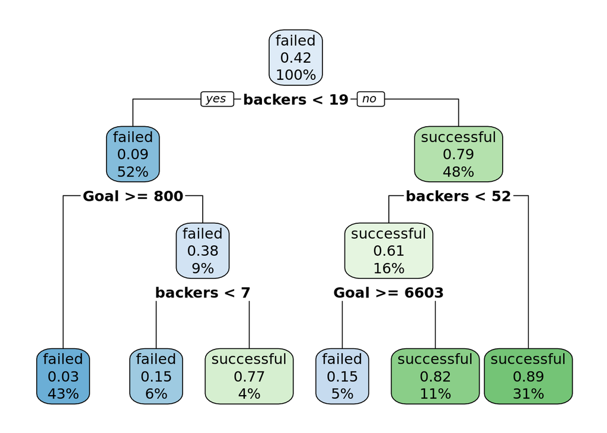

Проверим точность модели на обучающей и тестовой выборке.

**Обучающая выборка**

|  | failed | successful |
| --- | --- | --- |
| failed | 17694 | 1014 |
| successful | 2242 | 13718 |

| x |
| --- |
| 0.9060805 |

**Тестовая выборка**

|  | failed | successful |
| --- | --- | --- |
| failed | 4434 | 260 |
| successful | 536 | 3437 |

| x |
| --- |
| 0.9081574 |

Точность модели 0.9060805 (около 90%) на обучающей выборке и 0.9081574 (около 91%) на тестовой выборке. Эта модель гораздо точнее предыдущей. Данная модель показывает **условия**, при которых проект может стать успешным. Согласно ним, есть три варианта, в которых проект будет успешным:

1. Если спонсоров меньше 19, то целевая сумма должна быть меньше 800 и количество спонсоров должно быть 7 или больше.

Если количество спонсоров 19 и больше:

2. Если количество спосоров меньше 52, то целевая сумма должна быть меньше 6603.
3. Если количество спонсоров 52 или больше, то проект успешен.

Из модели мы можем сделать вывод, что, так как другие параметры не так сильно влияют на успешность проекта, то надо всеми силами привлечь как можно больше спонсоров. Однако не всегда можно предугадать количество спонсоров.

В остальных случаях вероятность провала больше.

### Выводы

- Самыми **главными условиями успешности проекта**, собирет ли он необходимую сумму, являются **количество спонсоров и целевая сумма**. Надо всеми силами привлечь как можно больше спонсоров.
- Есть *три варианта*, в которых велика вероятность, что проект будет успешным:
  1. Если *спонсоров меньше 19*, то *целевая сумма должна быть меньше 800* и *количество спонсоров должно быть минимум 7*.
  2. Если количество *спонсоров 19 и больше, но меньше 52*, то *целевая сумма должна быть меньше 6603*.
  3. Если количество *спонсоров 52 или больше*, то проект успешен.
- Чтобы **увеличить шансы на успех**, независимо от спонсоров, количество которых не предугадать при решении создания проекта, следует выбрать одну из категорий *Art, Comics, Dance, Design, Games, Music, Theater*, иметь *целевую сумму меньше 30437* и
  1. если *собирать деньги меньше 30 дней*, то возможность успеха около 67 процентов.
  2. если *собирать деньги больше 30 дней*, то тогда, чтобы быть успешным (с вероятностью около 57 процентов), надо *назвать проект длиной не меньше 21 символа* и *собирать деньги меньше 55 дней*.

### Дэшборд

Полученные выводы обобщены в виде дэшборда со следующими элементами

**Элемент 1:**

- вид: дерево
- обоснование: Самый важный график - это дерево, которое показывает как можно увеличить шансы того, что проект будет успешным, независимо от количества спонсоров, которых нельзя “задать” при создании проекта на Kickstarter. Это то, на что заказчик должен обратить внимание.

**Элемент 2:**

- вид: число (проценты)
- обоснование: Процентная доля успешности проектов показывает, какова вероятность успеха без учета выявленных закономерностей, то есть как бы действовал человек, не проанализировав данные.

**Элемент 3:**

- вид: график
- обоснование: График изображает долю успешных проектов в каждой главной категории кампании с выделением категорий, которые были показаны в дереве как способствующие успеху. Данный график нагляднее показывает, как увеличить шансы собрать полную целевую сумму.

**Элемент 4:**

- вид: число (проценты)
- обоснование: Процентная доля успешности при соблюдении правил показывает важность их соблюдения на контрасте с упомянутой выше процентной долей успешности без их учета.